# Us Police Shooting

Jamelehija-Adedokhan-Aseel Khamis

6/5/2021

## Background

In this markdown,We Are going to analyze this data set:https://www.kaggle.com/ahsen1330/us-police-shootings of United states police shooting.

1. Is the age normally distributed?
2. Is there a correlation between being armed, the race of the neutralized person and age?
3. Is the age and race correlated with attacking?

Our main goal in this research is to check if the adults are the most armed or attacking people from different races. based on this, we will use the age almost in every model or visualization.

## importing the data set

The dataset is an csv file, so we used read.csv to read it

## Transformation,Visualization,and Modelling the data

1. Transformations:

–First of all, we took specific columns which are important for our research.

–The first mutation is for all different age groups in our data set, starting from children finishing in Elders.

–The second mutation is to check whether the person had any kind of mental illness and at the same time if he attacked the police during the incident.

–The third and fourth mutations is to check whether the shooted person was armed/attacking.

–The fifth mutation, and the last, is to Minimize the races into two main races (Black and White), obviously in US they are whether black or white even though they are Hispanic/Asian…

2. Visualization:

Lets take a look of all age groups and the states that we are going to visualize!

```r
shooting_data%>%
  group_by(age_group)%>%
  summarize()
```

```
## # A tibble: 5 x 1
##   age_group
##   <chr>
## 1 adults
## 2 children
## 3 Elders
## 4 teens
## 5 youth
```

```r
shooting_data%>%
  group_by(state)%>%
  summarize()
```

```
## # A tibble: 51 x 1
##    state
##    <chr>
##  1 AK
##  2 AL
##  3 AR
##  4 AZ
##  5 CA
##  6 CO
##  7 CT
##  8 DC
##  9 DE
## 10 FL
## # ... with 41 more rows
```

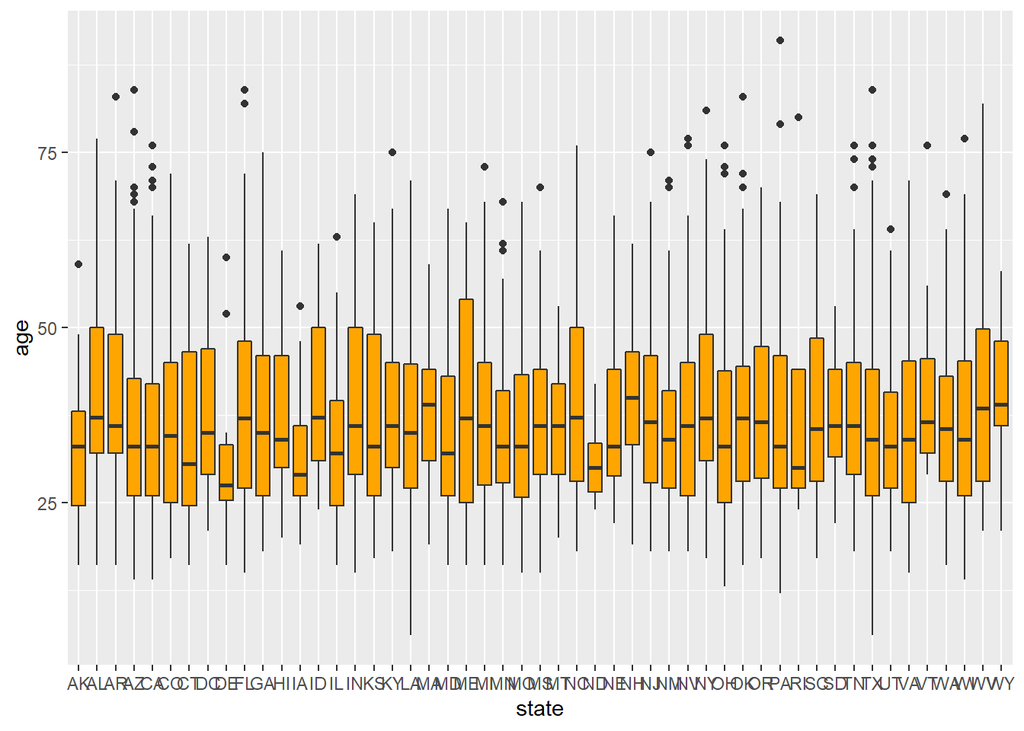

```r
ggplot(shooting_data,aes(x=state,y=age,fill(state)))+
  geom_boxplot(fill="orange")
```

We can clearly see that the average age across all states is in the 29-45 range, the adults group. To confirm this, we can look at the age group at which the most people were killed, relative to other groups:

```r
agekilled<-shooting_data%>%
  count(age_group)%>%
  view()
agekilled
```

```
##   age_group    n
## 1    adults 2366
## 2  children    4
## 3    Elders  741
## 4     teens  358
## 5     youth 1426
```

The answer is adults, as we expected.

As known, the US is very large country and it’s very important to show the death reports across the states, so now lets take a look at the map all around the US in order to see in which places shootings are most common.

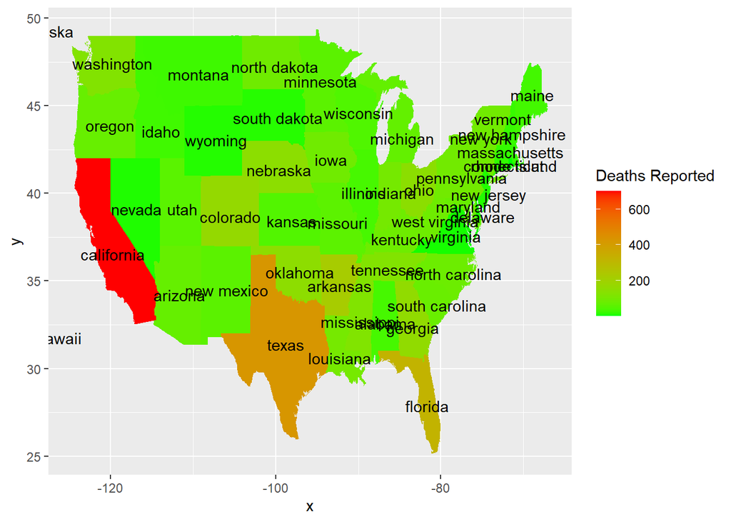

```r
k <-shooting_data %>%
    group_by(state) %>%
    arrange(state) %>%
    tally()
k<-k[-c(8),]
states <- data.frame(state_abb = state.abb, state_names=state.name)
new_data <- cbind(k, states)
l <- new_data %>% select(state_names, n)
l$state_names <- tolower(l$state_names)
centroid <- data.frame(region=tolower(state.name), long=state.center$x, lat=state.center$y)
l <- cbind(l, centroid) %>% select(-region)
map <- map_data("state")
l %>% ggplot(aes(fill=n)) +
    geom_map(aes(map_id=state_names), map=map) +
    expand_limits(x = map$long, y = map$lat) +
    scale_fill_gradient(low="green", high="red", name="Deaths Reported") +
    geom_text(x=l$long, y=l$lat, label=l$state_names)
```

very interesting map, California in first place, second is Texas and so on.

3. Modeling:

At first, lets start with the first hypothesis: age is normally distributed:

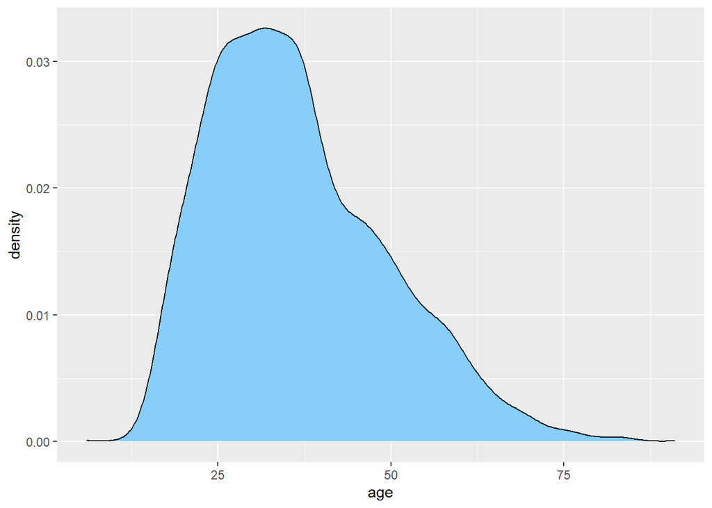

```r
ggplot(data=shooting_data, aes(x=age),main="Density plot of the age")+
  geom_density(fill="lightskyblue")
```

```r
shapiro.test(shooting_data$age)
```

```
##
##  Shapiro-Wilk normality test
##
## data:  shooting_data$age
## W = 0.96061, p-value < 2.2e-16
```

We can see here a distribution big one hump in the middle and acting like normal distribution, the possible explanation for that is: most of the people were shot are between ages 25-50, which proves more our main research goal, but lets take a look of the results we get from shapiro test for normal distribution:

The p-value is lower than 0.05, so we can say in significance level of 0.05 that the age is not normally distributed, so we reject the null hypothesis.

Now, lets move on to our second question: Is there a correlation between race, armed of the neutralized person and age?

First of all, we start with showing a boxplot of people armed by age:

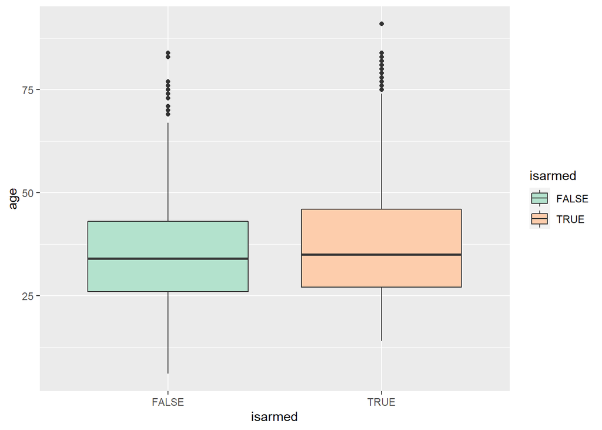

```r
ggplot(shooting_data,aes(x = isarmed, y = age,fill =isarmed))+
  geom_boxplot()+
  scale_fill_brewer(palette = "Pastel2")
```

Lets check this by the results to decide whether there is a correlation or not. also, we are adding the variable race, according to the goal we have set.

First We Use the cor() function to test the relationship between our independent variables (attacking and armed) and to make sure they aren’t too highly correlated.

```r
cor(shooting_data$isarmed,shooting_data$isattacking)
```

```
## [1] 0.3640925
```

```r
fitade<-lm(formula= log10(age)~ isarmed + isattacking + race,data = shooting_data)%>%
  summary()
fitade
```

```
##
## Call:
## lm(formula = log10(age) ~ isarmed + isattacking + race, data = shooting_data)
##
## Residuals:
##     Min      1Q  Median      3Q     Max
## -0.7598 -0.1048  0.0010  0.1055  0.3926
##
## Coefficients:
##                 Estimate Std. Error t value Pr(>|t|)
## (Intercept)     1.470580   0.005275 278.783  < 2e-16 ***
## isarmedTRUE     0.023202   0.004558   5.090 3.72e-07 ***
## isattackingTRUE 0.006020   0.004725   1.274    0.203
## racewhite       0.067395   0.004771  14.125  < 2e-16 ***
## ---
## Signif. codes:  0 '***' 0.001 '**' 0.01 '*' 0.05 '.' 0.1 ' ' 1
##
## Residual standard error: 0.1472 on 4891 degrees of freedom
## Multiple R-squared:  0.04509,    Adjusted R-squared:  0.0445
## F-statistic: 76.98 on 3 and 4891 DF,  p-value: < 2.2e-16
```

Along with that if we take the fourth row we can clearly see that the white race people get shot -the bigger age they are(in the adults group range).

Now lets move to check our final question: is there a correlation between the age and attacking?

```r
fitgen<-lm(formula = log1p(isattacking)~age+race, data= shooting_data)%>%
  summary()
fitgen
```

```
##
## Call:
## lm(formula = log1p(isattacking) ~ age + race, data = shooting_data)
##
## Residuals:
##     Min      1Q  Median      3Q     Max
## -0.5163 -0.4340  0.2290  0.2536  0.2846
##
## Coefficients:
##               Estimate Std. Error t value Pr(>|t|)
## (Intercept)  0.4226283  0.0153994  27.444  < 2e-16 ***
## age          0.0013384  0.0003796   3.525 0.000427 ***
## racewhite   -0.0327689  0.0109167  -3.002 0.002698 **
## ---
## Signif. codes:  0 '***' 0.001 '**' 0.01 '*' 0.05 '.' 0.1 ' ' 1
##
## Residual standard error: 0.3311 on 4892 degrees of freedom
## Multiple R-squared:  0.003682,   Adjusted R-squared:  0.003275
## F-statistic:  9.04 on 2 and 4892 DF,  p-value: 0.0001206
```

```r
fit2<-lm(formula = log1p(isattacking) ~ age, data = shooting_data)
summary(fit2)
```

```
##
## Call:
## lm(formula = log1p(isattacking) ~ age, data = shooting_data)
##
## Residuals:
##     Min      1Q  Median      3Q     Max
## -0.5007 -0.4379  0.2339  0.2519  0.2710
##
## Coefficients:
##              Estimate Std. Error t value Pr(>|t|)
## (Intercept) 0.4064331  0.0144352  28.156  < 2e-16 ***
## age         0.0011227  0.0003731   3.009  0.00263 **
## ---
## Signif. codes:  0 '***' 0.001 '**' 0.01 '*' 0.05 '.' 0.1 ' ' 1
##
## Residual standard error: 0.3313 on 4893 degrees of freedom
## Multiple R-squared:  0.001847,   Adjusted R-squared:  0.001643
## F-statistic: 9.055 on 1 and 4893 DF,  p-value: 0.002634
```

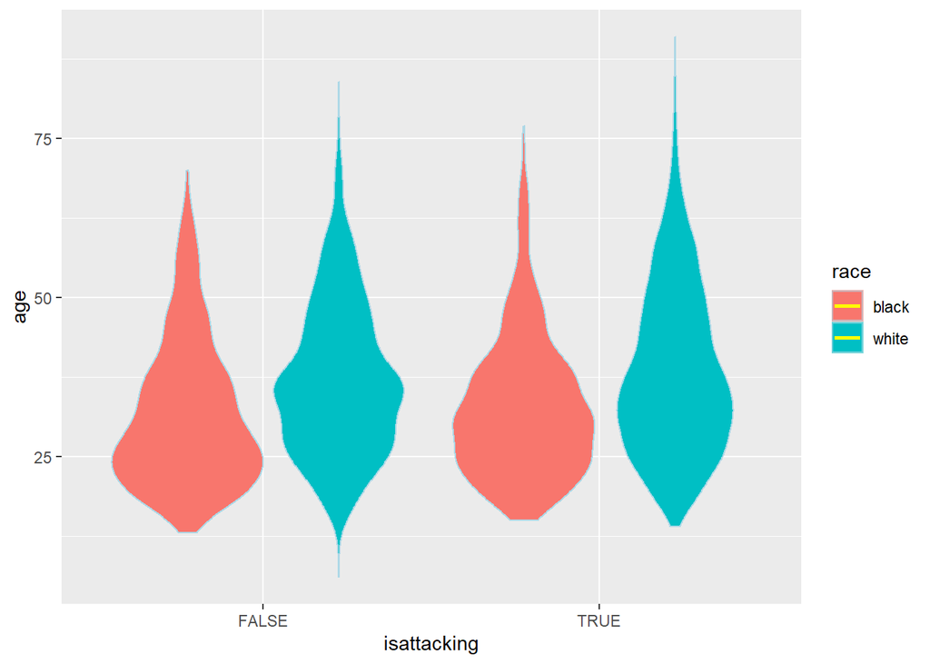

```r
shooting_data %>%
  ggplot(aes(y=age, x= isattacking,fill=race))+
  geom_violin(color="lightblue")+
  stat_smooth(method = "lm",color="yellow")
```

*The first question, visualization showed a behavior that is very close to normal distribution but the results rejected they hypothesis

So to sum up, we clearly can see that’s the adults group are the ones with the highest numbers of attacking, shooting and being armed. which confirms our main research goal, checking if the adults are the most active age group in police shooting situations.

We had a hard time as a team searching at this data-set, because almost every variable is noncontinuous and every variable shows very different information from the other which makes it hard for us to find a correlation between them and finding a relationships. We think that’s the maximum information we can get from a small data-set with such irrelevant variables.

Thank you for reading and we hope that you enjoyed!